# Calculating tidal levels for MI/OPW Data

Author

Fernando Mayer, Niamh Cahill, Niamh Mimnagh

Published

October 10, 2026

# GalwayPort

## Introduction

The aim of this document is to explore tide-level data from the Marine Institute (MI) and the Office of Public Works (OPW). The final result should be to obtain the tidal levels for each station in Ireland where the MI/OPW has available data.

## Data

```r
## Packages
library(arrow)
library(tidyverse)
library(patchwork)
library(TideHarmonics)
here::i_am("index.qmd")
source(here::here("scripts", "_functions.R"))
theme_set(theme_bw() + theme(legend.position = "right", legend.direction = "vertical"))


## Full dataset
fl <- here::here("data", "merged_tide_gauge_data", "iteration_a_qc1")
da <- open_dataset(fl, format="parquet")


## Filter for station
db <- da |>
    filter(st_id == params$station, QC_Flag == 1) |>
    mutate(year = year(time), .before = "station_id") |>
    mutate(QC_Flag = NULL, sea_level = Water_Level_OD_Malin, Water_Level_OD_Malin = NULL) |>
    arrange(time) |>
    collect()

db |>
  slice_head(n = 100) |>
  knitr::kable(digits = 3, format = "html", format.args = list(big.mark = ",")) |>
  kableExtra::kable_styling(full_width = TRUE, bootstrap_options = c("striped", "hover", "condensed")) |>
  kableExtra::scroll_box(height = "500px", fixed_thead = TRUE)
```

| time | year | station_id | st_id | latitude | longitude | source_station_id | source_station_code | datum | datum_status | source | sea_level |
| --- | --- | --- | --- | --- | --- | --- | --- | --- | --- | --- | --- |
| 2007-03-15 18:48:00 | 2,007 | Galway Port | GalwayPort | 53.269 | -9.048 | Galway Port | NA | OD Malin | Confirmed MI field | MI | -0.733 |
| 2007-03-15 18:54:00 | 2,007 | Galway Port | GalwayPort | 53.269 | -9.048 | Galway Port | NA | OD Malin | Confirmed MI field | MI | -0.798 |
| 2007-03-15 19:00:00 | 2,007 | Galway Port | GalwayPort | 53.269 | -9.048 | Galway Port | NA | OD Malin | Confirmed MI field | MI | -0.877 |
| 2007-03-15 19:06:00 | 2,007 | Galway Port | GalwayPort | 53.269 | -9.048 | Galway Port | NA | OD Malin | Confirmed MI field | MI | -0.926 |
| 2007-03-15 19:12:00 | 2,007 | Galway Port | GalwayPort | 53.269 | -9.048 | Galway Port | NA | OD Malin | Confirmed MI field | MI | -0.983 |
| 2007-03-15 19:18:00 | 2,007 | Galway Port | GalwayPort | 53.269 | -9.048 | Galway Port | NA | OD Malin | Confirmed MI field | MI | -1.046 |
| 2007-03-15 19:24:00 | 2,007 | Galway Port | GalwayPort | 53.269 | -9.048 | Galway Port | NA | OD Malin | Confirmed MI field | MI | -1.089 |
| 2007-03-15 19:30:00 | 2,007 | Galway Port | GalwayPort | 53.269 | -9.048 | Galway Port | NA | OD Malin | Confirmed MI field | MI | -1.132 |
| 2007-03-15 19:36:00 | 2,007 | Galway Port | GalwayPort | 53.269 | -9.048 | Galway Port | NA | OD Malin | Confirmed MI field | MI | -1.180 |
| 2007-03-15 19:42:00 | 2,007 | Galway Port | GalwayPort | 53.269 | -9.048 | Galway Port | NA | OD Malin | Confirmed MI field | MI | -1.209 |
| 2007-03-15 19:48:00 | 2,007 | Galway Port | GalwayPort | 53.269 | -9.048 | Galway Port | NA | OD Malin | Confirmed MI field | MI | -1.225 |
| 2007-03-15 19:54:00 | 2,007 | Galway Port | GalwayPort | 53.269 | -9.048 | Galway Port | NA | OD Malin | Confirmed MI field | MI | -1.288 |
| 2007-03-15 20:00:00 | 2,007 | Galway Port | GalwayPort | 53.269 | -9.048 | Galway Port | NA | OD Malin | Confirmed MI field | MI | -1.316 |
| 2007-03-15 20:06:00 | 2,007 | Galway Port | GalwayPort | 53.269 | -9.048 | Galway Port | NA | OD Malin | Confirmed MI field | MI | -1.344 |
| 2007-03-15 20:12:00 | 2,007 | Galway Port | GalwayPort | 53.269 | -9.048 | Galway Port | NA | OD Malin | Confirmed MI field | MI | -1.371 |
| 2007-03-15 20:18:00 | 2,007 | Galway Port | GalwayPort | 53.269 | -9.048 | Galway Port | NA | OD Malin | Confirmed MI field | MI | -1.387 |
| 2007-03-15 20:24:00 | 2,007 | Galway Port | GalwayPort | 53.269 | -9.048 | Galway Port | NA | OD Malin | Confirmed MI field | MI | -1.391 |
| 2007-03-15 20:30:00 | 2,007 | Galway Port | GalwayPort | 53.269 | -9.048 | Galway Port | NA | OD Malin | Confirmed MI field | MI | -1.397 |
| 2007-03-15 20:36:00 | 2,007 | Galway Port | GalwayPort | 53.269 | -9.048 | Galway Port | NA | OD Malin | Confirmed MI field | MI | -1.398 |
| 2007-03-15 20:42:00 | 2,007 | Galway Port | GalwayPort | 53.269 | -9.048 | Galway Port | NA | OD Malin | Confirmed MI field | MI | -1.397 |
| 2007-03-15 20:48:00 | 2,007 | Galway Port | GalwayPort | 53.269 | -9.048 | Galway Port | NA | OD Malin | Confirmed MI field | MI | -1.373 |
| 2007-03-15 20:54:00 | 2,007 | Galway Port | GalwayPort | 53.269 | -9.048 | Galway Port | NA | OD Malin | Confirmed MI field | MI | -1.365 |
| 2007-03-15 21:00:00 | 2,007 | Galway Port | GalwayPort | 53.269 | -9.048 | Galway Port | NA | OD Malin | Confirmed MI field | MI | -1.343 |
| 2007-03-15 21:06:00 | 2,007 | Galway Port | GalwayPort | 53.269 | -9.048 | Galway Port | NA | OD Malin | Confirmed MI field | MI | -1.310 |
| 2007-03-15 21:12:00 | 2,007 | Galway Port | GalwayPort | 53.269 | -9.048 | Galway Port | NA | OD Malin | Confirmed MI field | MI | -1.272 |
| 2007-03-15 21:18:00 | 2,007 | Galway Port | GalwayPort | 53.269 | -9.048 | Galway Port | NA | OD Malin | Confirmed MI field | MI | -1.242 |
| 2007-03-15 21:24:00 | 2,007 | Galway Port | GalwayPort | 53.269 | -9.048 | Galway Port | NA | OD Malin | Confirmed MI field | MI | -1.233 |
| 2007-03-15 21:30:00 | 2,007 | Galway Port | GalwayPort | 53.269 | -9.048 | Galway Port | NA | OD Malin | Confirmed MI field | MI | -1.181 |
| 2007-03-15 21:36:00 | 2,007 | Galway Port | GalwayPort | 53.269 | -9.048 | Galway Port | NA | OD Malin | Confirmed MI field | MI | -1.157 |
| 2007-03-15 21:42:00 | 2,007 | Galway Port | GalwayPort | 53.269 | -9.048 | Galway Port | NA | OD Malin | Confirmed MI field | MI | -1.147 |

[output cut: 70 more lines]

```r
## Save the name for posterior use
station_id <- unique(db$station_id)
st_id <- gsub(" ", "", station_id)

## Check dates
dtab <- db |> summarise(dmin = min(time), dmax = max(time))
```

This document examines the data for GalwayPort, where:

- The total number of observations is 1487725
- The first observation was recorded on 2007-03-15 18:48:00
- The last observation was recorded on 2024-10-03 13:00:00

The graph below shows the number of observations per year.

From 2021 onwards, the number of observations increases to over 100,000 per year. This increase is consistent with the change in sampling frequency identified in the exploratory analysis, where Galway Port transitions from approximately 6-minute to 5-minute sampling. The larger annual counts in these later years therefore do not necessarily represent improved completeness, but instead the greater number of observations expected when measurements are recorded more frequently.

The very low observation count in 2024 should also be interpreted carefully. The abrupt decline occurs at the end of the available record and is consistent with 2024 being a partial calendar year, rather than indicating a sudden deterioration in the quality or operation of the Galway Port gauge.

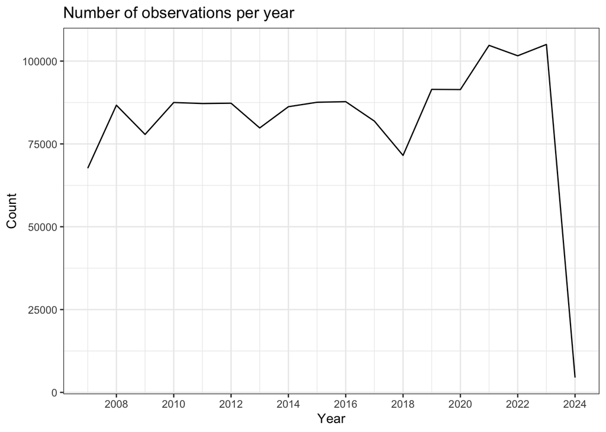

```r
## Count time series
db |>
    count(year) |>
    ggplot(aes(x = year, y = n)) +
    geom_line() +
    scale_x_continuous(breaks = scales::pretty_breaks(n = 10)) +
    labs(x = "Year", y = "Count", title = "Number of observations per year")
```

The following figure provides a closer view of the Galway Port water-level time series at three temporal scales, showing the full observational record as well as shorter sections, in order to see the tidal signal clearly.

The upper panel shows the complete record from March 2007 to October 2024. Water levels generally fluctuate between approximately −3 m and +3 m OD Malin.

The middle panel shows approximately the first six weeks of the record and demonstrates the regular tidal oscillation that is hidden when the complete series is displayed. The amplitude of the tide varies through time, with alternating periods of larger and smaller tidal ranges.

The lower panel provides a view over approximately four days. At this scale, the predominantly semidiurnal nature of the tide at Galway Port is evident, with approximately two high waters and two low waters occurring each day.

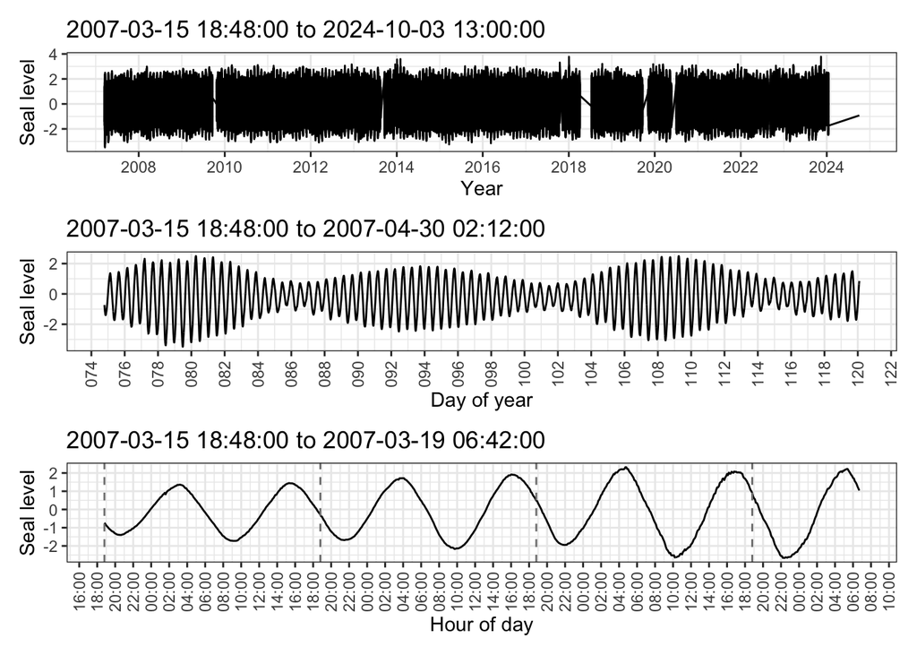

```r
## Full range
p1 <- db |>
    ggplot(aes(time, sea_level)) +
    geom_line() +
    scale_x_datetime(date_breaks = "2 years", date_minor_breaks = "1 year", date_labels = "%Y") +
    labs(title = sprintf("%s to %s", dtab$dmin, dtab$dmax), x = "Year", y = "Seal level")

dtab <- dtab |>
    mutate(smin = db |> slice_head(n = 5 * 90 * 24) |> pull(time) |> min(), smax = db |> slice_head(n = 5 * 90 * 24) |> pull(time) |> max())
p2 <- db |>
    filter(time >= dtab$smin, time <= dtab$smax) |>
    ggplot(aes(time, sea_level)) +
    geom_line() +
    scale_x_datetime(date_breaks = "2 days", date_minor_breaks = "1 day", date_labels = "%j") +
    labs(title = sprintf("%s to %s", dtab$smin, dtab$smax), x = "Day of year", y = "Seal level") +
    theme(axis.text.x = element_text(angle = 90, vjust = 0.5))

dtab <- dtab |>
    mutate(hmin = db |> slice_head(n = 5 * 7 * 24) |> pull(time) |> min(), hmax = db |> slice_head(n = 5 * 7 * 24) |> pull(time) |> max())
p3 <- db |>
    filter(time >= dtab$hmin, time <= dtab$hmax) |>
    ggplot(aes(time, sea_level)) +
    geom_line() +
    geom_vline(xintercept = seq(dtab$hmin, dtab$hmax, by = "day"), linetype = "dashed", color = "gray50", alpha = 1) +
    scale_x_datetime(date_breaks = "2 hours", date_minor_breaks = "1 hour", date_labels = "%R") +
    labs(title = sprintf("%s to %s", dtab$hmin, dtab$hmax), x = "Hour of day", y = "Seal level") +
    theme(axis.text.x = element_text(angle = 90, vjust = 0.5))
p1/p2/p3
```

The following figure summarises the annual behaviour and overall distribution of observed water levels at Galway Port.

The upper panel shows the annual minimum, maximum and mean sea level from 2007 to 2024. The annual mean sea level remains close to 0 m OD Malin throughout the record, with modest year-to-year variation.

The annual extremes show greater variability, as expected. Maximum observed water levels are generally around 3–3.5 m OD Malin, while annual minima are typically around −3 m OD Malin.

The lower panel shows the distribution of all observed water levels across the complete Galway Port record. Water levels span approximately −3 to +3 m OD Malin, with most observations lying between roughly −2 and +2 m.There is no obvious evidence here of the type of persistent anomaly identified previously for Kinvara–Unreferenced.

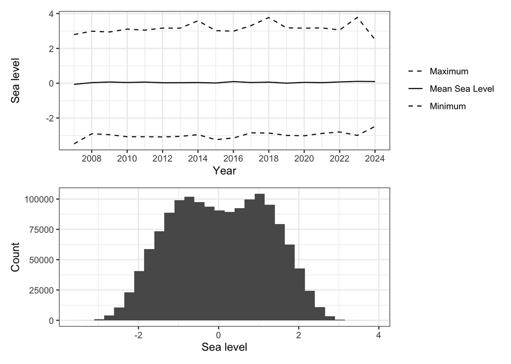

```r
## Get a rough view of variations
p1 <- db |>
    group_by(year) |>
    summarise(max = max(sea_level), msl = mean(sea_level), min = min(sea_level)) |>
    pivot_longer(cols = c(max, msl, min), names_to = "stat", values_to = "sea_level") |>
    ggplot(aes(x = year, y = sea_level, linetype = stat)) +
    geom_line() +
    scale_linetype_manual(
        values = c("max" = "dashed", "msl" = "solid", "min" = "dashed"),
        breaks = c("max", "msl", "min"),
        labels = c("max" = "Maximum", "msl" = "Mean Sea Level", "min" = "Minimum")) +
    scale_x_continuous(breaks = scales::pretty_breaks(n = 10)) +
    labs(x = "Year", y = "Sea level", linetype = "")
p2 <- db |>
    ggplot() +
    geom_histogram(aes(x = sea_level)) +
    labs(x = "Sea level", y = "Count")
p1/p2
```

To check the sample interval, all the differences between two consecutive times were calculated, and the number of such intervals is shown below.

The following table shows that the Galway Port record is dominated by two sampling intervals: 6 minutes and 5 minutes, as was seen in the exploratory analysis stage. Approximately 63.1% of consecutive observations are separated by 6 minutes, while 36.8% are separated by 5 minutes. Together, these account for almost all observations in the record.

A small number of other intervals, such as 10, 12 and 15 minutes, occur occasionally. These represent only a very small proportion of the dataset and are likely associated with individual missing observations or short interruptions in the series.

The very large intervals shown in the final rows represent gaps in the observational record rather than alternative sampling frequencies. Some of these gaps extend over many hours or days, consistent with the interruptions visible in the full Galway Port time series.

```r
## Time difference between observations
## In minutes
db <- db |> mutate(dtime = as.numeric(difftime(time, lag(time), units = "mins")))

## Check the dominant sample interval
db |>
    count(dtime) |>
    mutate(prop = n/sum(n)) |>
    arrange(desc(n)) |>
    head() |>
    knitr::kable(digits = 3) |>
    kableExtra::kable_styling(font_size = 8)
db |>
    count(dtime) |>
    mutate(prop = n/sum(n)) |>
    arrange(desc(n)) |>
    tail() |>
    knitr::kable(digits = 3) |>
    kableExtra::kable_styling(font_size = 8)
```

First 6 lines {#tbl-anonymous-3544581-1}

| dtime | n | prop |
| --- | --- | --- |
| 6 | 939418 | 0.631 |
| 5 | 547284 | 0.368 |
| 10 | 582 | 0.000 |
| 12 | 161 | 0.000 |
| 15 | 78 | 0.000 |
| 66 | 42 | 0.000 |

Last 6 lines {#tbl-anonymous-3544581-2}

| dtime | n | prop |
| --- | --- | --- |
| 49812 | 1 | 0 |
| 59295 | 1 | 0 |
| 66655 | 1 | 0 |
| 142785 | 1 | 0 |
| 375785 | 1 | 0 |
| NA | 1 | 0 |

```r
## This is the completed and standardised to 10-minutes sampling time
db_comp <- db |>
    select(-c(year, station_id, dtime)) |>
    mutate(time_rounded = floor_date(time, "10 min")) |>
    complete(time_rounded = seq(min(time_rounded), max(time_rounded), by = "10 min")) |>
    group_by(time_rounded) |>
    summarise(
        sea_level = mean(sea_level, na.rm = TRUE), # interpolation by mean
        n_obs = n(), # number of obs used in interpolation
        n_na  = sum(is.na(sea_level)), # total number of missing values
        .groups = "drop") |>
    rename(time = time_rounded) |>
    distinct(time, .keep_all = TRUE) |>
    arrange(time) |>
    mutate(sea_level = ifelse(is.nan(sea_level), NA_real_, sea_level), dtime = as.numeric(difftime(time, lag(time), units = "mins")))



## Check the last complete year
year_last <- db_comp |>
    mutate(year = year(time), month = month(time)) |>
    group_by(year) |>
    summarise(
        min_month = min(month(time)),
        max_month = max(month(time)),
        n_months = n_distinct(month(time)),
        .groups = "drop") |>
    filter(min_month == 1, max_month == 12, n_months == 12) |>
    slice_max(year, n = 1) |>
    pull(year)


## Also identify the first complete year
year_first <- db_comp |>
    mutate(year = year(time), month = month(time)) |>
    group_by(year) |>
    summarise(
        min_month = min(month(time)),
        max_month = max(month(time)),
        n_months = n_distinct(month(time)),
        .groups = "drop"
    ) |>
    filter(min_month == 1, max_month == 12, n_months == 12) |>
    slice_min(year, n = 1) |>
    pull(year)


## Create a vector for all year range
year_all <- year_first:year_last



## Use data for this range
db_comp <- db_comp |>
    filter(year(time) >= year_first, year(time) <= year_last) |>
    arrange(time)

dtab_comp <- db_comp |>
    summarise(dmin = min(time), dmax = max(time))
```

The next stage prepares the observed record for tidal harmonic analysis by placing the data on a 10-minute temporal grid. Observations are assigned to 10-minute time intervals, with multiple observations falling within the same interval combined using their mean. Time points for which no observations are available are retained as missing values, allowing gaps in the original record to remain explicitly represented in the standardised series.

The analysis then identifies the first and last complete calendar years within the standardised record.

The standardised dataset is subsequently restricted to the period between these first and last complete calendar years. This produces a common, regularly spaced time series covering the usable portion of the station record, which can then be used to construct the different analysis windows required for estimating tidal characteristics. In this case, the first full year is 2008, and the last full year is 2023, giving in total a range of 16 years.

The final dataset has then 841536 observations, with a 10 minute sample interval:

- The first observation is on 2008-01-01
- The last observation is on 2023-12-31 23:50:00

## Model

### Model fit

Next we define the rolling time windows used for the tidal harmonic analysis. Separate sets of overlapping windows are created for 3-year and 5-year periods, together with the longest available period of 16-years. Each of the 3-year and 5-year windows advance by one year, allowing tidal characteristics to be estimated repeatedly through time and compared across different record lengths.

The rolling windows used in the analysis are displayed in the table below, recording the window-length and the first- and last- years of each fitting period, making it easy to see exactly which portions of the record will be used in each model fit.

```r
## Create a list with all possible combinations of years to fit
k <- c(3, 5, length(year_all))
seq <- map(k, \(x) seq_win(year_all, k = x, step = 1))
## Set names
names(seq) <- sprintf("y_%s", k)
for(i in seq_along(seq)) {
    names(seq[[i]]) <- sprintf("y%s_%s", sapply(seq[[i]], \(x) max(x)), sapply(seq[[i]], \(x) min(x)))
}
##------------------------------------------------------------------------------
## Display rolling windows as a tidy table

window_table <- imap_dfr(seq, \(window_list, window_name) {
          imap_dfr(window_list, \(years, window_id) {
                tibble(window_size = as.integer(str_remove(window_name, "y_")),
                    first_year = min(years),
                    last_year = max(years))
            }
        )
    }
) |>
    arrange(window_size, desc(last_year))

window_table |>
    knitr::kable(col.names = c("Window size (years)", "Beginning year", "Last year"), caption = "Time windows used for tidal harmonic analysis") |>
    kableExtra::kable_styling(font_size = 9, full_width = FALSE)
```

Time windows used for tidal harmonic analysis

| Window size (years) | Beginning year | Last year |
| --- | --- | --- |
| 3 | 2021 | 2023 |
| 3 | 2020 | 2022 |
| 3 | 2019 | 2021 |
| 3 | 2018 | 2020 |
| 3 | 2017 | 2019 |
| 3 | 2016 | 2018 |
| 3 | 2015 | 2017 |
| 3 | 2014 | 2016 |
| 3 | 2013 | 2015 |
| 3 | 2012 | 2014 |
| 3 | 2011 | 2013 |
| 3 | 2010 | 2012 |
| 3 | 2009 | 2011 |
| 3 | 2008 | 2010 |
| 5 | 2019 | 2023 |
| 5 | 2018 | 2022 |
| 5 | 2017 | 2021 |
| 5 | 2016 | 2020 |
| 5 | 2015 | 2019 |
| 5 | 2014 | 2018 |
| 5 | 2013 | 2017 |
| 5 | 2012 | 2016 |
| 5 | 2011 | 2015 |
| 5 | 2010 | 2014 |
| 5 | 2009 | 2013 |
| 5 | 2008 | 2012 |
| 16 | 2008 | 2023 |

```r
## Create a list to hold model results
res <- vector(mode = "list", length = length(seq))
for(i in seq_along(res)) {
    res[[i]] <- vector("list", length(seq[[i]]))
}
## Use same names
names(res) <- names(seq)
for(i in seq_along(res)) {
    names(res[[i]]) <- names(seq[[i]])
}

## Fit all
for(i in seq_along(res)) {
    for(j in seq_along(res[[i]])) {
        t1 <- make_datetime(year = min(seq[[i]][[j]]))
        t2 <- make_datetime(year = max(seq[[i]][[j]]), month = 12, day = 31, hour = 23, min = 50)
        n1 <- names(seq)[[i]]
        n2 <- names(seq[[i]])[[j]]
        fl <- here::here("rds", sprintf("fit-%s-%s-%s.rds", n1, n2, st_id))
        if(!file.exists(fl)) {
            res[[i]][[j]] <- with(subset(db_comp, time >= t1 & time <= t2), fit_th(x = sea_level, dto = time, pred = FALSE))
            saveRDS(res[[i]][[j]], fl)
        } else {
            res[[i]][[j]] <- readRDS(fl)
        }
    }
}
```

### Model results

#### Tidal constituents

K1, O1, M2, and S2 are the main tidal constituents because they represent the dominant astronomical forcing mechanisms and typically have the largest amplitudes.

- Semi-diurnal constituents (2 cycles per day):
  - **M2** (Principal lunar semi-diurnal): The largest tidal constituent in most places. Period = 12.42 hours. Caused by the moon’s gravitational pull as Earth rotates beneath it.
  - **S2** (Principal solar semi-diurnal): Second largest semi-diurnal constituent. Period = 12.00 hours. Caused by the sun’s gravitational pull.
- Diurnal constituents (1 cycle per day):
  - **K1** (Lunisolar diurnal): Largest diurnal constituent. Period = 23.93 hours. Results from the declination of the moon and sun.
  - **O1** (Principal lunar diurnal): Second largest diurnal constituent. Period = 25.82 hours. Due to lunar declination effects.

Why these four matters:

1. **Largest amplitudes**: They typically account for 70-90% of tidal variance
2. **Physical significance**:
   - M2 & S2 create spring-neap cycles (14-day variation)
   - K1 & O1 create diurnal inequality (different heights of successive high/low tides)
3. **Tidal classification**: The form factor (K1+O1)/(M2+S2) uses these to classify whether tides are semi-diurnal, diurnal, or mixed
4. **Coastal features**: MHWS, MLWS, etc. are primarily defined by M2 and S2

The following figure shows how the estimated amplitudes of the four tidal constituents — K1, M2, O1 and S2 — vary through time at Galway Port. Results are shown separately for the rolling 3-year (y_3) and 5-year (y_5) fitting windows. The red dashed line provides a reference value for each constituent, allowing changes in the rolling estimates to be viewed relative to the longer-term estimate.

The clearest temporal changes occur for the two semidiurnal constituents, M2 and S2. M2 has the largest amplitude, confirming that it is the dominant constituent among those shown. Its estimated amplitude is relatively high in the earlier windows before declining noticeably from around 2012–2015. It subsequently stabilises at a lower level. S2 exhibits a very similar pattern, falling from approximately 0.566 m in the earliest windows to around 0.550–0.552 m in the later part of the record. The similarity between the 3- and 5-year results suggests that these patterns are not simply an artefact of the particular window length used.

K1 shows a smaller but still systematic change through time. Its amplitude initially increases slightly, before declining in the later windows. By approximately 2018 onwards, both the 3- and 5-year estimates lie below the reference value.

In contrast, O1 is relatively stable. Its amplitude is much smaller, and although the 3-year estimates fluctuate somewhat, there is no change comparable in magnitude to that seen for M2 and S2. The smoother 5-year estimates remain close to the longer-term reference for much of the record.

As expected, the 3-year windows show greater short-term variability, whereas the 5-year windows produce smoother trajectories because each estimate incorporates a longer period of observations. Importantly, however, the main temporal patterns are broadly consistent between the two window lengths.

These temporal changes in the estimated tidal constituents may be expected to subsequently feed into the estimates of derived tidal characteristics such as MHWS, MHWN, MLWN and MLWS, which motivates modelling the tidal features through time rather than relying only on a single estimate calculated from the entire record.

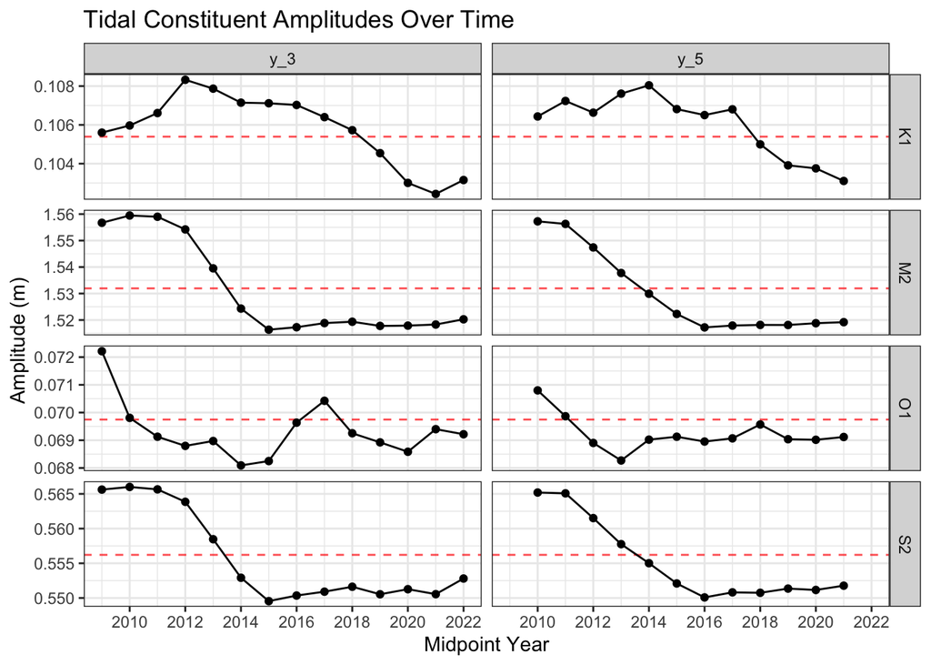

```r
## Extract constituent amplitudes
constituent_amps <- map(res, \(x) map(x, \(y) {
  coefs <- y$coefficients
  tibble(
    K1 = sqrt(coefs["K1_C"]^2 + coefs["K1_S"]^2),
    O1 = sqrt(coefs["O1_C"]^2 + coefs["O1_S"]^2),
    M2 = sqrt(coefs["M2_C"]^2 + coefs["M2_S"]^2),
    S2 = sqrt(coefs["S2_C"]^2 + coefs["S2_S"]^2)
  )
})) |>
  imap_dfr(function(window_list, window_name) {
    imap_dfr(window_list, function(amps, year_range) {
      amps |>
        mutate(window_size = window_name, year_range = year_range, .before = 1)
    })
  }) |>
  mutate(
    n_years = as.integer(str_extract(window_size, "\\d+")),
    year_end = as.integer(str_extract(year_range, "(?<=y)\\d+")),
    year_start = as.integer(str_extract(year_range, "\\d+$")),
    year_mid = (year_start + year_end) / 2) |>
  pivot_longer(cols = c(K1, O1, M2, S2), names_to = "constituent", values_to = "amplitude")

## Plot
## Extract the last values for plotting
ly <- constituent_amps$window_size |> tail(1)
amps_ref <- constituent_amps |>
    filter(window_size == ly) |>
    select(constituent, amplitude)
## Plot with horizontal reference lines
constituent_amps |>
    filter(window_size != ly) |>
    ggplot(aes(x = make_datetime(year_mid), y = amplitude)) +
    geom_hline(data = amps_ref, aes(yintercept = amplitude), linetype = "dashed", color = "red", alpha = 0.7) +
    geom_line() +
    geom_point() +
    facet_grid(constituent ~ window_size, scales = "free_y") +
    scale_x_datetime(date_breaks = "2 year", date_minor_breaks = "1 year", date_labels = "%Y") +
    labs(x = "Midpoint Year", y = "Amplitude (m)", title = "Tidal Constituent Amplitudes Over Time")
```

#### Form factor

The form factor is calculated by

$$(K1+O1)/(M2+S2)$$

and it classifies tides as:

- < 0.25: Semi-diurnal
- 0.25-1.5: Mixed, mainly semi-diurnal
- 1.5-3.0: Mixed, mainly diurnal
- > 3.0: Diurnal

The following figure shows how the tidal form factor at Galway Port varies through time, estimated using the rolling 3-year and 5-year fitting windows. The red dashed line represents the form factor estimated from the longer-term record and provides a reference against which the rolling estimates can be compared.

The form factor remains within a very narrow range, approximately 0.083–0.086, throughout the record. Both window lengths show a similar pattern: values are relatively low in the earlier windows, increase to a maximum around 2014–2017, and decline again towards the later years.

The 3-year estimates show somewhat greater year-to-year variability, as expected because they are calculated from shorter periods of data. The 5-year estimates are smoother, but reproduce the same general rise and subsequent decline. This agreement indicates that the pattern is not simply a consequence of the choice of rolling-window length.

Most importantly, the form factor remains well below 0.25 throughout the entire record. This indicates that Galway Port has a semidiurnal tidal regime.

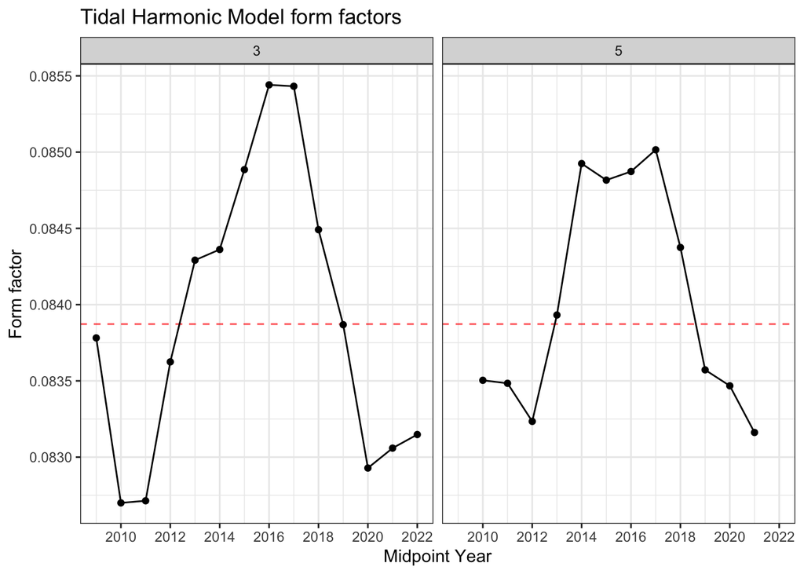

```r
fval_data <- map(res, \(x) map(x, \(y) y$fval)) |>
    imap_dfr(function(window_list, window_name) {
        imap_dfr(window_list, function(fval, year_range) {
            tibble(window_size = window_name, year_range = year_range, fval = fval)
        })
    }) |>
    mutate(
        # Extract numeric window size (3, 5, 16)
        n_years = as.integer(str_extract(window_size, "\\d+")),
        # Extract years from "y2023_2021" format
        year_end = as.integer(str_extract(year_range, "(?<=y)\\d+")),
        year_start = as.integer(str_extract(year_range, "\\d+$")),
        # Calculate midpoint year for plotting
        year_mid = (year_start + year_end) / 2
    )

## Plot
## Get reference value
fval_ref <- fval_data |>
    filter(window_size == ly) |>
    select(fval) |>
    pull()
## Plot with horizontal reference line
fval_data |>
    filter(window_size != ly) |>
    ggplot(aes(x = year_mid, y = fval)) +
    geom_hline(yintercept = fval_ref, linetype = "dashed", color = "red", alpha = 0.7) +
    geom_line() +
    geom_point() +
    facet_wrap(~ n_years) +
    scale_x_continuous(breaks = scales::pretty_breaks(n = 10)) +
    labs(x = "Midpoint Year", y = "Form factor", title = "Tidal Harmonic Model form factors")
```

#### Tidal levels

Tidal levels (or features) are defined as:

- **HAT** (Highest Astronomical Tide) = maximum predicted astronomical tide over the reference prediction period
- **MSL** (Mean Sea Level) = mean of the time series (or the constant/mean term in the model)
- **MHWS** (Mean High Water Springs) = MSL + M2$_{\text{amp}}$ + S2$_{\text{amp}}$
- **MHWN** (Mean High Water Neaps) = MSL + M2$_{\text{amp}}$ - S2$_{\text{amp}}$
- **MLWN** (Mean Low Water Neaps) = MSL - M2$_{\text{amp}}$ + S2$_{\text{amp}}$
- **MLWS** (Mean Low Water Springs) = MSL - M2$_{\text{amp}}$ - S2$_{\text{amp}}$
- **LAT** (Lowest Astronomical Tide) = minimum predicted astronomical tide over the reference prediction period

Where:

- **M2** = principal lunar semi-diurnal (largest constituent)
- **S2** = principal solar semi-diurnal

Springs occur when M2 and S2 are in phase (add together), creating the highest highs and lowest lows.

Neaps occur when M2 and S2 are out of phase (subtract), creating smaller tidal ranges.

The following figure shows the estimated tidal levels at Galway Port through time, derived from the harmonic models fitted using rolling 3-year and 5-year windows. The tidal characteristics shown are HAT, MHWS, MHWN, MSL, MLWN, MLWS and LAT. The red dashed lines provide the corresponding longer-term estimates for comparison.

In earlier windows, the high-water levels (particularly HAT and MHWS) tend to be higher, while the low-water levels (particularly MLWS and LAT) tend to be lower. Moving into the middle and later parts of the record, the high-water estimates generally decrease and the low-water estimates become less negative. This indicates a narrowing of the estimated tidal range relative to the earlier part of the record.

This pattern is particularly evident for HAT and LAT. HAT declines from around 3.0 m in the earlier windows to around 2.9 m in the later windows, while LAT moves from values below approximately −3.0 m towards values closer to −2.9 m. Similar, though smaller, changes are visible for MHWS and MLWS. These patterns are consistent with the earlier constituent analysis, where the amplitudes of the dominant semidiurnal constituents M2 and S2 decreased between the earlier and later fitting windows.

The intermediate tidal levels, MHWN and MLWN, also vary through time but over a narrower range. MHWN generally decreases during the first half of the record before showing some recovery in the most recent windows, while MLWN becomes less negative overall.

In contrast, MSL remains comparatively stable, fluctuating only by a few centimetres around approximately 0.04–0.05 m OD Malin.

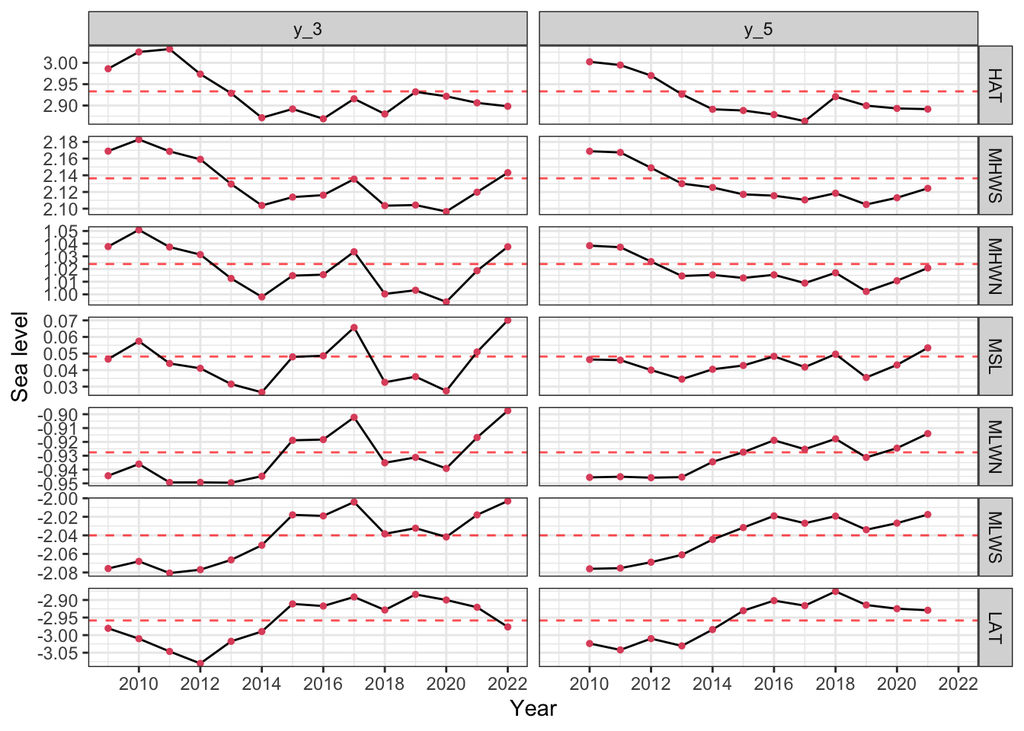

```r
## Calculate HAT and LAT for every fitted window.

lat_hat_dir <- here::here("rds", "lat-hat")
dir.create(lat_hat_dir, recursive = TRUE, showWarnings = FALSE)

hat_lat_data <- imap_dfr(res, function(window_list, window_name) {
    imap_dfr(window_list, function(fit, year_range) {

        lat_hat_file <- here::here("rds", "lat-hat", sprintf("lat-hat-%s-%s-%s.rds", window_name, year_range, st_id))

        if(file.exists(lat_hat_file)) {
            lat_hat <- readRDS(lat_hat_file)
        } else {
            lat_hat <- calculate_lat_hat(fit = fit)
            saveRDS(lat_hat, lat_hat_file)
        }

        lat_hat |>
            select(constituent, value) |>
            mutate(window_size = window_name, year_range = year_range, .before = 1)
    })
}) |>
    mutate(
        n_years = as.integer(str_extract(window_size, "\\d+")),
        year_end = as.integer(str_extract(year_range, "(?<=y)\\d+")),
        year_start = as.integer(str_extract(year_range, "\\d+$")),
        year_mid = (year_start + year_end) / 2
    )

features1_data <- map(res, \(x) map(x, \(y) y$features1)) |>
    imap_dfr(function(window_list, window_name) {
        imap_dfr(window_list, function(features1_mat, year_range) {
            # Convert matrix to tibble
            as_tibble(features1_mat, rownames = "constituent") |>
                mutate(window_size = window_name, year_range = year_range, .before = 1)
        })
    }) |>
    mutate(
        # Extract numeric window size (3, 5, 16)
        n_years = as.integer(str_extract(window_size, "\\d+")),
        # Extract years from "y2023_2021" format
        year_end = as.integer(str_extract(year_range, "(?<=y)\\d+")),
        year_start = as.integer(str_extract(year_range, "\\d+$")),
        # Calculate midpoint year for plotting
        year_mid = (year_start + year_end) / 2,
        constituent = factor(constituent,
            levels = c("MHWS", "MHWN", "MSL", "MLWN", "MLWS"))
    )


## Add HAT and LAT to the existing tidal features
features1_data <- bind_rows(features1_data, hat_lat_data) |>
    mutate(constituent = factor(constituent, levels = c("HAT", "MHWS", "MHWN", "MSL", "MLWN", "MLWS", "LAT")))


## Plot
# Extract the last window_size values
features1_ref <- features1_data |>
    filter(window_size == ly) |>
    select(constituent, value)
# Plot with horizontal reference lines
features1_data |>
    filter(window_size != ly) |>
    ggplot(aes(x = make_datetime(year_mid), y = value)) +
    geom_hline(data = features1_ref, aes(yintercept = value), linetype = "dashed", color = "red", alpha = 0.7) +
    geom_line() +
    geom_point(size = 1, color = 2) +
    facet_grid(constituent ~ window_size, scales = "free_y") +
    scale_x_datetime(date_breaks = "2 year", date_minor_breaks = "1 year", date_labels = "%Y") +
    labs(x = "Year", y = "Sea level")
```

The table below shows the actual values.

```r
features1_data |>
    select(n_years, year_end, year_start, constituent, value) |>
    pivot_wider(names_from = constituent, values_from = value) |>
    arrange(n_years, desc(year_end)) |>
    knitr::kable(digits = 3, caption = "Tidal Constituents by Window Size and Year Range") |>
    kableExtra::kable_styling(font_size = 8)
```

Tidal Constituents by Window Size and Year Range

| n_years | year_end | year_start | MLWS | MLWN | MSL | MHWN | MHWS | LAT | HAT |
| --- | --- | --- | --- | --- | --- | --- | --- | --- | --- |
| 3 | 2023 | 2021 | -2.003 | -0.897 | 0.070 | 1.038 | 2.143 | -2.977 | 2.898 |
| 3 | 2022 | 2020 | -2.018 | -0.917 | 0.051 | 1.019 | 2.120 | -2.921 | 2.906 |
| 3 | 2021 | 2019 | -2.042 | -0.939 | 0.027 | 0.994 | 2.097 | -2.900 | 2.922 |
| 3 | 2020 | 2018 | -2.032 | -0.931 | 0.036 | 1.003 | 2.104 | -2.884 | 2.932 |
| 3 | 2019 | 2017 | -2.038 | -0.935 | 0.033 | 1.000 | 2.104 | -2.929 | 2.880 |
| 3 | 2018 | 2016 | -2.004 | -0.902 | 0.066 | 1.034 | 2.135 | -2.891 | 2.916 |
| 3 | 2017 | 2015 | -2.019 | -0.918 | 0.049 | 1.016 | 2.116 | -2.917 | 2.869 |
| 3 | 2016 | 2014 | -2.018 | -0.919 | 0.048 | 1.015 | 2.114 | -2.911 | 2.892 |
| 3 | 2015 | 2013 | -2.051 | -0.945 | 0.027 | 0.998 | 2.104 | -2.990 | 2.871 |
| 3 | 2014 | 2012 | -2.066 | -0.950 | 0.032 | 1.013 | 2.130 | -3.018 | 2.929 |
| 3 | 2013 | 2011 | -2.077 | -0.949 | 0.041 | 1.031 | 2.159 | -3.081 | 2.974 |
| 3 | 2012 | 2010 | -2.081 | -0.949 | 0.044 | 1.037 | 2.169 | -3.046 | 3.032 |
| 3 | 2011 | 2009 | -2.068 | -0.936 | 0.057 | 1.051 | 2.183 | -3.010 | 3.025 |
| 3 | 2010 | 2008 | -2.076 | -0.944 | 0.047 | 1.038 | 2.169 | -2.981 | 2.986 |
| 5 | 2023 | 2019 | -2.018 | -0.914 | 0.053 | 1.021 | 2.124 | -2.929 | 2.892 |
| 5 | 2022 | 2018 | -2.027 | -0.925 | 0.043 | 1.011 | 2.113 | -2.925 | 2.893 |
| 5 | 2021 | 2017 | -2.034 | -0.931 | 0.036 | 1.002 | 2.105 | -2.914 | 2.900 |
| 5 | 2020 | 2016 | -2.019 | -0.918 | 0.050 | 1.017 | 2.119 | -2.876 | 2.921 |
| 5 | 2019 | 2015 | -2.027 | -0.925 | 0.042 | 1.009 | 2.111 | -2.916 | 2.863 |
| 5 | 2018 | 2014 | -2.019 | -0.919 | 0.048 | 1.015 | 2.116 | -2.902 | 2.879 |
| 5 | 2017 | 2013 | -2.032 | -0.927 | 0.043 | 1.013 | 2.117 | -2.930 | 2.888 |
| 5 | 2016 | 2012 | -2.044 | -0.934 | 0.040 | 1.015 | 2.125 | -2.984 | 2.891 |
| 5 | 2015 | 2011 | -2.061 | -0.945 | 0.035 | 1.015 | 2.130 | -3.031 | 2.926 |
| 5 | 2014 | 2010 | -2.069 | -0.946 | 0.040 | 1.026 | 2.149 | -3.010 | 2.970 |
| 5 | 2013 | 2009 | -2.075 | -0.945 | 0.046 | 1.037 | 2.167 | -3.042 | 2.995 |
| 5 | 2012 | 2008 | -2.076 | -0.946 | 0.046 | 1.038 | 2.169 | -3.024 | 3.002 |
| 16 | 2023 | 2008 | -2.040 | -0.928 | 0.048 | 1.024 | 2.136 | -2.958 | 2.933 |

```r
fl <- here::here("rds", sprintf("features-%s.rds", st_id))
saveRDS(features1_data, fl)
```